# Resolución de problemas

```r
# Librerías y carga de funciones
source("teoria_decision_funciones_incertidumbre.R")
library(ggplot2)
library(knitr)
library(kableExtra)
```

## 1. Primer problema: Resolución de tabla de decisión con los métodos vistos en clase.

Usaremos una tabla de decisión con los mismos datos que la tarea realizado en Excel para la clase de teoría, así podremos comparar si los resultados son iguales.

Al final de cada apartado pondremos una tabla resumen con todas las decisiones obtenidas.

```r
pb1_datos <- crea.tablaX(c( 80, 60, 90, 70, 85, 75,
                95, 55, 65, 60, 70, 80,
                50, 45, 55, 60, 65, 70,
                90, 85, 95, 80, 75, 100,
                70, 60, 65, 55, 60, 65),
    numalternativas = 5, numestados = 6
)
alfaH <- 0.4 # Establecemos un nivel de alfa para el criterio de Hurwicz
```

```r
kable(pb1_datos, caption = "Tabla de decisión")
```

Tabla de decisión

|  | e1 | e2 | e3 | e4 | e5 | e6 |
| --- | --- | --- | --- | --- | --- | --- |
| d1 | 80 | 60 | 90 | 70 | 85 | 75 |
| d2 | 95 | 55 | 65 | 60 | 70 | 80 |
| d3 | 50 | 45 | 55 | 60 | 65 | 70 |
| d4 | 90 | 85 | 95 | 80 | 75 | 100 |
| d5 | 70 | 60 | 65 | 55 | 60 | 65 |

### 1.1 Resolución en el caso favorable (beneficios)

```r
waldfav <- criterio.Wald(pb1_datos, favorable = TRUE)#favorable = TRUE se refiere a beneficios
optfav <- criterio.Optimista(pb1_datos, favorable = TRUE)
hurfav <- criterio.Hurwicz(pb1_datos, alfa = alfaH, favorable =TRUE)
savagefav <- criterio.Savage(pb1_datos, favorable = TRUE)#pesos son las pérdidas
laplacefav <- criterio.Laplace(pb1_datos, favorable = TRUE)
idealfav <- criterio.PuntoIdeal(pb1_datos, favorable = TRUE)
waldfav
```

```
$criterio
[1] "Wald"

$metodo
[1] "favorable"

$tablaX
   e1 e2 e3 e4 e5  e6
d1 80 60 90 70 85  75
d2 95 55 65 60 70  80
d3 50 45 55 60 65  70
d4 90 85 95 80 75 100
d5 70 60 65 55 60  65

$ValorAlternativas
d1 d2 d3 d4 d5
60 55 45 75 55

$ValorOptimo
[1] 75

$AlternativaOptima
d4
 4
```

```r
optfav
```

```
$criterio
[1] "Optimista"

$metodo
[1] "favorable"

$tablaX
   e1 e2 e3 e4 e5  e6
d1 80 60 90 70 85  75
d2 95 55 65 60 70  80
d3 50 45 55 60 65  70
d4 90 85 95 80 75 100
d5 70 60 65 55 60  65

$ValorAlternativas
 d1  d2  d3  d4  d5
 90  95  70 100  70

$ValorOptimo
[1] 100

$AlternativaOptima
d4
 4
```

```r
hurfav
```

```
$criterio
[1] "Hurwicz"

$alfa
[1] 0.4

$metodo
[1] "favorable"

$tablaX
   e1 e2 e3 e4 e5  e6
d1 80 60 90 70 85  75
d2 95 55 65 60 70  80
d3 50 45 55 60 65  70
d4 90 85 95 80 75 100
d5 70 60 65 55 60  65

$ValorAlternativas
d1 d2 d3 d4 d5
72 71 55 85 61

$ValorOptimo
[1] 85

$AlternativaOptima
d4
 4
```

```r
savagefav
```

```
$criterio
[1] "Savage"

$metodo
[1] "favorable"

$tablaX
   e1 e2 e3 e4 e5  e6
d1 80 60 90 70 85  75
d2 95 55 65 60 70  80
d3 50 45 55 60 65  70
d4 90 85 95 80 75 100
d5 70 60 65 55 60  65

$Mejores
 e1  e2  e3  e4  e5  e6
 95  85  95  80  85 100

$Pesos
   e1 e2 e3 e4 e5 e6
d1 15 25  5 10  0 25
d2  0 30 30 20 15 20
d3 45 40 40 20 20 30
d4  5  0  0  0 10  0
d5 25 25 30 25 25 35

$ValorAlternativas
d1 d2 d3 d4 d5
25 30 45 10 35

$ValorOptimo
[1] 10

$AlternativaOptima
d4
 4
```

```r
laplacefav
```

```
$criterio
[1] "Laplace"

$metodo
[1] "favorable"

$tablaX
   e1 e2 e3 e4 e5  e6
d1 80 60 90 70 85  75
d2 95 55 65 60 70  80
d3 50 45 55 60 65  70
d4 90 85 95 80 75 100
d5 70 60 65 55 60  65

$ValorAlternativas
      d1       d2       d3       d4       d5
76.66667 70.83333 57.50000 87.50000 62.50000

$ValorOptimo
[1] 87.5

$AlternativaOptima
d4
 4
```

```r
idealfav
```

```
$criterio
[1] "Punto Ideal"

$metodo
[1] "favorable"

$tablaX
   e1 e2 e3 e4 e5  e6
d1 80 60 90 70 85  75
d2 95 55 65 60 70  80
d3 50 45 55 60 65  70
d4 90 85 95 80 75 100
d5 70 60 65 55 60  65

$Mejores
 e1  e2  e3  e4  e5  e6
 95  85  95  80  85 100

$ValorAlternativas
      d1       d2       d3       d4       d5
40.00000 53.15073 83.21658 11.18034 68.00735

$ValorOptimo
[1] 11.18034

$AlternativaOptima
d4
 4
```

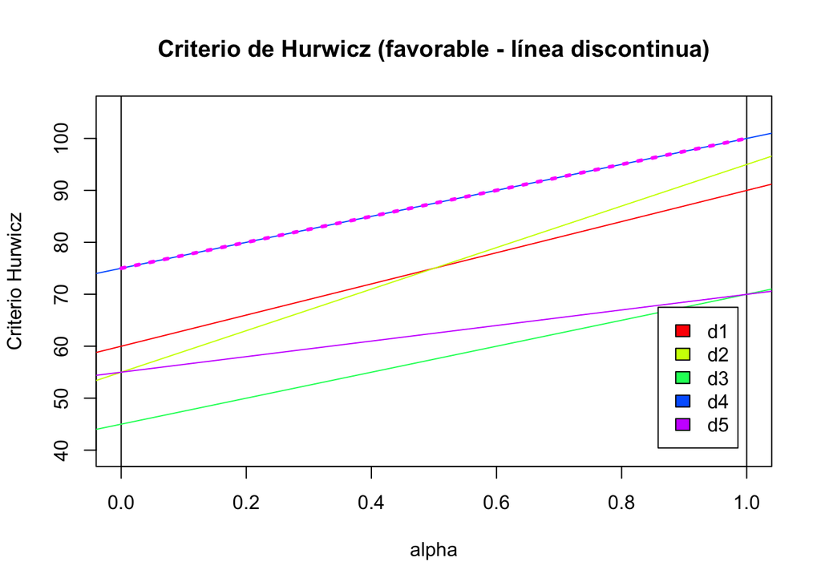

```r
#Rectas del método Hurwicz
dibuja.criterio.Hurwicz(pb1_datos, favorable = TRUE)
```

```r
#dibuja.criterio.Hurwicz_Intervalos(pb1_datos, favorable = TRUE) No hay puntos de corte porque d4 es la mejor para cualquier valor de alpha
```

A continuación se ofrece una tabla resumen de la elección para cada uno de los criterios, que nos ayudará para la decisión final.

```r
resumenfav <- data.frame(
Criterio = c("Wald", "Optimista", "Hurwicz", "Savage","Laplace","Punto Ideal"),
AlternativaOptima = c(
  names(waldfav$AlternativaOptima),
  names(optfav$AlternativaOptima),
  names(hurfav$AlternativaOptima),
  names(savagefav$AlternativaOptima),
  names(laplacefav$AlternativaOptima),
  names(idealfav$AlternativaOptima)
)
)

library(kableExtra)
kable(resumenfav, caption = paste("Decisión óptima según cada criterio (α =", alfaH, ")")) |>
kable_styling(bootstrap_options = c("striped", "hover", "condensed"))
```

Decisión óptima según cada criterio (α = 0.4 )

| Criterio | AlternativaOptima |
| --- | --- |
| Wald | d4 |
| Optimista | d4 |
| Hurwicz | d4 |
| Savage | d4 |
| Laplace | d4 |
| Punto Ideal | d4 |

**Decisión**: En todos los criterios la mejor alternativa en el caso favorable es la **d4**. Esto resultados están acorde a lo calculado con Excel.

### 1.2 Resolución en el caso desfavorable (costos)

Calculamos la mejor decisión con cada criterio para el caso desfavorable

```r
walddes <- criterio.Wald(pb1_datos, favorable = FALSE)
optdes <- criterio.Optimista(pb1_datos, favorable = FALSE)
hurdes <- criterio.Hurwicz(pb1_datos, alfa = alfaH, favorable =FALSE)
savagedes <- criterio.Savage(pb1_datos, favorable = FALSE)
laplacedes <- criterio.Laplace(pb1_datos, favorable = FALSE)
idealdes <- criterio.PuntoIdeal(pb1_datos, favorable = FALSE)

walddes
```

```
$criterio
[1] "Wald"

$metodo
[1] "desfavorable"

$tablaX
   e1 e2 e3 e4 e5  e6
d1 80 60 90 70 85  75
d2 95 55 65 60 70  80
d3 50 45 55 60 65  70
d4 90 85 95 80 75 100
d5 70 60 65 55 60  65

$ValorAlternativas
 d1  d2  d3  d4  d5
 90  95  70 100  70

$ValorOptimo
[1] 70

$AlternativaOptima
d3 d5
 3  5
```

```r
optdes
```

```
$criterio
[1] "Optimista"

$metodo
[1] "desfavorable"

$tablaX
   e1 e2 e3 e4 e5  e6
d1 80 60 90 70 85  75
d2 95 55 65 60 70  80
d3 50 45 55 60 65  70
d4 90 85 95 80 75 100
d5 70 60 65 55 60  65

$ValorAlternativas
d1 d2 d3 d4 d5
60 55 45 75 55

$ValorOptimo
[1] 45

$AlternativaOptima
d3
 3
```

```r
hurdes
```

```
$criterio
[1] "Hurwicz"

$alfa
[1] 0.4

$metodo
[1] "desfavorable"

$tablaX
   e1 e2 e3 e4 e5  e6
d1 80 60 90 70 85  75
d2 95 55 65 60 70  80
d3 50 45 55 60 65  70
d4 90 85 95 80 75 100
d5 70 60 65 55 60  65

$ValorAlternativas
d1 d2 d3 d4 d5
78 79 60 90 64

$ValorOptimo
[1] 60

$AlternativaOptima
d3
 3
```

```r
savagedes
```

```
$criterio
[1] "Savage"

$metodo
[1] "desfavorable"

$tablaX
   e1 e2 e3 e4 e5  e6
d1 80 60 90 70 85  75
d2 95 55 65 60 70  80
d3 50 45 55 60 65  70
d4 90 85 95 80 75 100
d5 70 60 65 55 60  65

$Mejores
e1 e2 e3 e4 e5 e6
50 45 55 55 60 65

$Pesos
   e1 e2 e3 e4 e5 e6
d1 30 15 35 15 25 10
d2 45 10 10  5 10 15
d3  0  0  0  5  5  5
d4 40 40 40 25 15 35
d5 20 15 10  0  0  0

$ValorAlternativas
d1 d2 d3 d4 d5
35 45  5 40 20

$ValorOptimo
[1] 5

$AlternativaOptima
d3
 3
```

```r
laplacedes
```

```
$criterio
[1] "Laplace"

$metodo
[1] "desfavorable"

$tablaX
   e1 e2 e3 e4 e5  e6
d1 80 60 90 70 85  75
d2 95 55 65 60 70  80
d3 50 45 55 60 65  70
d4 90 85 95 80 75 100
d5 70 60 65 55 60  65

$ValorAlternativas
      d1       d2       d3       d4       d5
76.66667 70.83333 57.50000 87.50000 62.50000

$ValorOptimo
[1] 57.5

$AlternativaOptima
d3
 3
```

```r
idealdes
```

```
$criterio
[1] "Punto Ideal"

$metodo
[1] "desfavorable"

$tablaX
   e1 e2 e3 e4 e5  e6
d1 80 60 90 70 85  75
d2 95 55 65 60 70  80
d3 50 45 55 60 65  70
d4 90 85 95 80 75 100
d5 70 60 65 55 60  65

$Mejores
e1 e2 e3 e4 e5 e6
50 45 55 55 60 65

$ValorAlternativas
       d1        d2        d3        d4        d5
57.445626 50.744458  8.660254 82.915620 26.925824

$ValorOptimo
[1] 8.660254

$AlternativaOptima
d3
 3
```

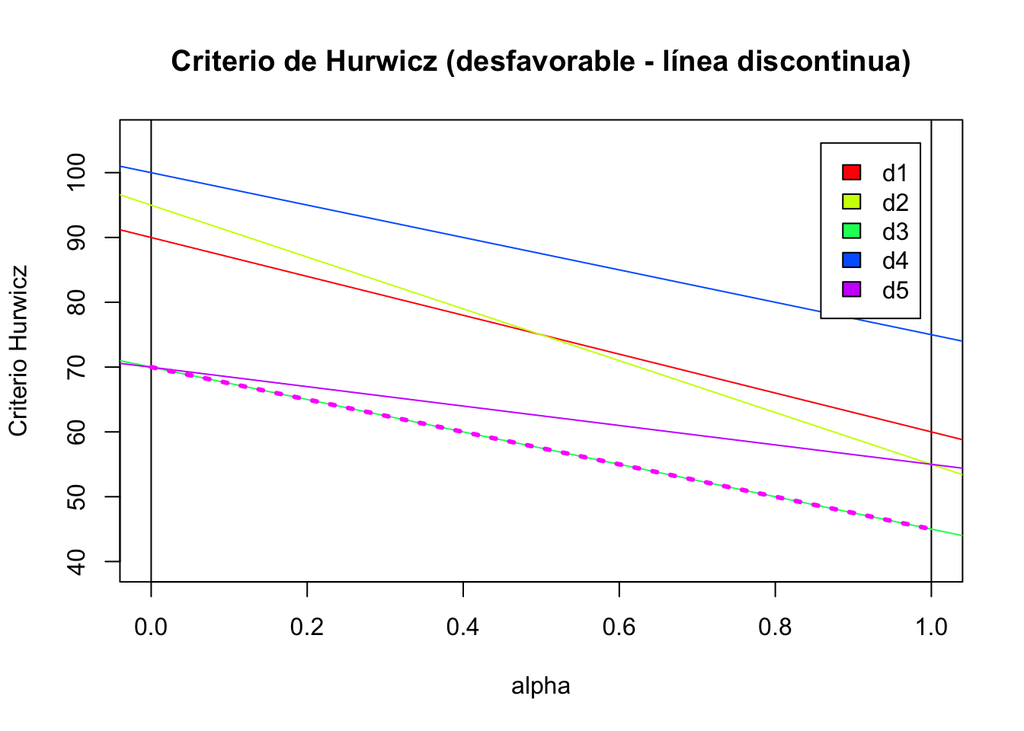

```r
#Rectas del método Hurwicz
dibuja.criterio.Hurwicz(pb1_datos, favorable = FALSE)
```

```r
#dibuja.criterio.Hurwicz_Intervalos(pb1_datos, favorable = FALSE) No hay puntos de corte porque d3 siempre es la mejor para cualquier valor de alpha
```

Se muestra ahora un resumen de los resultados para el caso desfavorable.

```r
resumendes <- data.frame(
Criterio = c("Wald", "Optimista", "Hurwicz", "Savage","Laplace","Punto Ideal"),
AlternativaOptima = c(
  paste(names(walddes$AlternativaOptima), collapse = ", "),
  names(optdes$AlternativaOptima),
  names(hurdes$AlternativaOptima),
  names(savagedes$AlternativaOptima),
  names(laplacedes$AlternativaOptima),
  names(idealdes$AlternativaOptima)
)
)
AlternativaOptima <-
library(kableExtra)
kable(resumendes, caption = paste("Decisión óptima según cada criterio (α =", alfaH, ")")) |>
kable_styling(bootstrap_options = c("striped", "hover", "condensed"))
```

Decisión óptima según cada criterio (α = 0.4 )

| Criterio | AlternativaOptima |
| --- | --- |
| Wald | d3, d5 |
| Optimista | d3 |
| Hurwicz | d3 |
| Savage | d3 |
| Laplace | d3 |
| Punto Ideal | d3 |

En el caso desfavorable elección mayoritaria será d3 en todos los criterios, sólo d5 se elige 1 vez en el criterio de Wald.

**Decisión**: La mejor alternativa en el caso desfavorable es la **d3**. Esto resultados están acorde a lo calculado con Excel.